# 数据加载与初步探索

```python
import pandas as pd
import numpy as np
```

```python
data = pd.read_csv('train.csv')
data.head()
```

|  | id | loanAmnt | term | interestRate | installment | grade | subGrade | employmentTitle | employmentLength | homeOwnership | ... | n5 | n6 | n7 | n8 | n9 | n10 | n11 | n12 | n13 | n14 |
| --- | --- | --- | --- | --- | --- | --- | --- | --- | --- | --- | --- | --- | --- | --- | --- | --- | --- | --- | --- | --- | --- |
| 0 | 0 | 35000.0 | 5 | 19.52 | 917.97 | E | E2 | 320.0 | 2 years | 2 | ... | 9.0 | 8.0 | 4.0 | 12.0 | 2.0 | 7.0 | 0.0 | 0.0 | 0.0 | 2.0 |
| 1 | 1 | 18000.0 | 5 | 18.49 | 461.90 | D | D2 | 219843.0 | 5 years | 0 | ... | NaN | NaN | NaN | NaN | NaN | 13.0 | NaN | NaN | NaN | NaN |
| 2 | 2 | 12000.0 | 5 | 16.99 | 298.17 | D | D3 | 31698.0 | 8 years | 0 | ... | 0.0 | 21.0 | 4.0 | 5.0 | 3.0 | 11.0 | 0.0 | 0.0 | 0.0 | 4.0 |
| 3 | 3 | 11000.0 | 3 | 7.26 | 340.96 | A | A4 | 46854.0 | 10+ years | 1 | ... | 16.0 | 4.0 | 7.0 | 21.0 | 6.0 | 9.0 | 0.0 | 0.0 | 0.0 | 1.0 |
| 4 | 4 | 3000.0 | 3 | 12.99 | 101.07 | C | C2 | 54.0 | NaN | 1 | ... | 4.0 | 9.0 | 10.0 | 15.0 | 7.0 | 12.0 | 0.0 | 0.0 | 0.0 | 4.0 |

5 rows × 47 columns

### 数据形状

```python
data.shape
```

```
(800000, 47)
```

```python
data_columns = data.columns.tolist()
data_columns
```

```
['id',
 'loanAmnt',
 'term',
 'interestRate',
 'installment',
 'grade',
 'subGrade',
 'employmentTitle',
 'employmentLength',
 'homeOwnership',
 'annualIncome',
 'verificationStatus',
 'issueDate',
 'isDefault',
 'purpose',
 'postCode',
 'regionCode',
 'dti',
 'delinquency_2years',
 'ficoRangeLow',
 'ficoRangeHigh',
 'openAcc',
 'pubRec',
 'pubRecBankruptcies',
 'revolBal',
 'revolUtil',
 'totalAcc',
 'initialListStatus',
 'applicationType',
 'earliesCreditLine',
 'title',
 'policyCode',
 'n0',
 'n1',
 'n2',
 'n3',
 'n4',
 'n5',
 'n6',
 'n7',
 'n8',
 'n9',
 'n10',
 'n11',
 'n12',
 'n13',
 'n14']
```

### 数据类型

```python
# 根据.info()的类型分析结果初步进行类型划分

data.info()
```

```
<class 'pandas.core.frame.DataFrame'>
RangeIndex: 800000 entries, 0 to 799999
Data columns (total 47 columns):
 #   Column              Non-Null Count   Dtype
---  ------              --------------   -----
 0   id                  800000 non-null  int64
 1   loanAmnt            800000 non-null  float64
 2   term                800000 non-null  int64
 3   interestRate        800000 non-null  float64
 4   installment         800000 non-null  float64
 5   grade               800000 non-null  object
 6   subGrade            800000 non-null  object
 7   employmentTitle     799999 non-null  float64
 8   employmentLength    753201 non-null  object
 9   homeOwnership       800000 non-null  int64
```

[output cut: 39 more lines]

```python
numerical_cols = data.select_dtypes(include = ['int64','float64']).columns.tolist()
categorical_cols = data.select_dtypes(include = ['object']).columns.tolist()

print('数值型变量')
print(numerical_cols)
print('分类变量')
print(categorical_cols)
```

```
数值型变量
['id', 'loanAmnt', 'term', 'interestRate', 'installment', 'employmentTitle', 'homeOwnership', 'annualIncome', 'verificationStatus', 'isDefault', 'purpose', 'postCode', 'regionCode', 'dti', 'delinquency_2years', 'ficoRangeLow', 'ficoRangeHigh', 'openAcc', 'pubRec', 'pubRecBankruptcies', 'revolBal', '…
分类变量
['grade', 'subGrade', 'employmentLength', 'issueDate', 'earliesCreditLine']
```

```python
# 根据以上结果，手动划分变量

target_cols = 'isDefault'
id_cols = 'id'
date_cols = ['issueDate','earliesCreditLine']

categorical_cols = ['homeOwnership','verificationStatus',
                   'purpose','regionCode','applicationType',
                   'initialListStatus','postCode','policyCode','title','employmentTitle']
ordinal_cols = ['term','grade','subGrade','employmentLength']

# 捕捉到employmentLength可能是职业代码编号，后续要特殊处理

numerical_cols_df = [col for col in data.columns
                 if col not in date_cols + categorical_cols + ordinal_cols + [target_cols,id_cols]]

# 因为每当修改dataframe之后numerical_cols都会变动，故创建新的列表用于后续数据处理
# 每次创建新的变量都在这里手动添加并删除旧列
numerical_cols = ['loanAmnt', 'interestRate', 'installment', 'annualIncome', 'delinquency_2years',
 'ficoRangeLow', 'ficoRangeHigh', 'openAcc', 'pubRec', 'pubRecBankruptcies', 'revolBal', 'revolUtil',
 'totalAcc',
 'n0', 'n1', 'n2', 'n3', 'n4', 'n5', 'n6', 'n7', 'n8', 'n9', 'n10', 'n11', 'n12', 'n13', 'n14'
                 ,'dti_cleaned','credit_history_years']


print('目标变量：',target_cols)
print('ID变量：',id_cols)
print('日期变量：',date_cols)
print('分类变量：',f'{len(categorical_cols)}个')
print(categorical_cols)
print('有序变量：')
print(ordinal_cols)
print('数值型变量：',f'{len(numerical_cols)}个')
print(numerical_cols)
```

[output not shown]

```python
print((len(date_cols) + len(categorical_cols) + len(ordinal_cols) + len(numerical_cols) + 2)==47)
```

```
True
```

```python
# 发现可以通过日期变量： ['issueDate', 'earliesCreditLine']构建新的变量，即信用历史长度，是很好的指标

# 'issueDate' 处理
data['issueDate_clean'] = pd.to_datetime(data['issueDate']) # 把原来字符串形式的日期，转换成pandas能识别的真正日期格式
data[['issueDate_clean','issueDate']].head(10)
data['issueYear'] = data['issueDate_clean'].dt.year # 提取年份和月份
data['issueMonth'] = data['issueDate_clean'].dt.month
data[['issueYear','issueMonth','issueDate']].head(10)
```

|  | issueYear | issueMonth | issueDate |
| --- | --- | --- | --- |
| 0 | 2014 | 7 | 2014-07-01 |
| 1 | 2012 | 8 | 2012-08-01 |
| 2 | 2015 | 10 | 2015-10-01 |
| 3 | 2015 | 8 | 2015-08-01 |
| 4 | 2016 | 3 | 2016-03-01 |
| 5 | 2017 | 4 | 2017-04-01 |
| 6 | 2014 | 10 | 2014-10-01 |
| 7 | 2014 | 1 | 2014-01-01 |
| 8 | 2016 | 5 | 2016-05-01 |
| 9 | 2015 | 11 | 2015-11-01 |

```python
# 'earliesCreditLine' 处理

data['earliesCreditLine'].head(10)
```

```
0    Aug-2001
1    May-2002
2    May-2006
3    May-1999
4    Aug-1977
5    Jul-1998
6    Oct-2006
7    Dec-1994
8    Apr-1994
9    Jan-1993
Name: earliesCreditLine, dtype: object
```

```python
data['earliesCreditLine_clean'] = pd.to_datetime(data['earliesCreditLine'], format = '%b-%Y')
# %b：英文缩写月份，比如 Jan, Feb, Aug, %Y：四位年份，比如 2001
data[['earliesCreditLine_clean','earliesCreditLine']].head(10)
```

|  | earliesCreditLine_clean | earliesCreditLine |
| --- | --- | --- |
| 0 | 2001-08-01 | Aug-2001 |
| 1 | 2002-05-01 | May-2002 |
| 2 | 2006-05-01 | May-2006 |
| 3 | 1999-05-01 | May-1999 |
| 4 | 1977-08-01 | Aug-1977 |
| 5 | 1998-07-01 | Jul-1998 |
| 6 | 2006-10-01 | Oct-2006 |
| 7 | 1994-12-01 | Dec-1994 |
| 8 | 1994-04-01 | Apr-1994 |
| 9 | 1993-01-01 | Jan-1993 |

```python
data['earliesYear'] = data['earliesCreditLine_clean'].dt.year
data['earliesMonth'] = data['earliesCreditLine_clean'].dt.month
data[['earliesYear','earliesMonth','earliesCreditLine']].head(10)
```

|  | earliesYear | earliesMonth | earliesCreditLine |
| --- | --- | --- | --- |
| 0 | 2001 | 8 | Aug-2001 |
| 1 | 2002 | 5 | May-2002 |
| 2 | 2006 | 5 | May-2006 |
| 3 | 1999 | 5 | May-1999 |
| 4 | 1977 | 8 | Aug-1977 |
| 5 | 1998 | 7 | Jul-1998 |
| 6 | 2006 | 10 | Oct-2006 |
| 7 | 1994 | 12 | Dec-1994 |
| 8 | 1994 | 4 | Apr-1994 |
| 9 | 1993 | 1 | Jan-1993 |

```python
# 构建信用历史长度'credit_history_years'

data['credit_history_years'] = data['issueYear'] - data['earliesYear']
data[['issueDate_clean','earliesCreditLine_clean','credit_history_years']].head(10)

# 将'credit_history_years'放入数值型变量
numerical_cols.append('credit_history_years')
len(numerical_cols)
```

```
30
```

### 缺失值统计

```python
# 统计缺失值数量和比例

missing_data = pd.DataFrame({
    'Missing Count': data.isnull().sum(),
    'Missing Ratio': data.isnull().mean()
}).sort_values('Missing Ratio', ascending = False)

missing_data.head(20)
```

|  | Missing Count | Missing Ratio |
| --- | --- | --- |
| n11 | 69752 | 0.087190 |
| employmentLength | 46799 | 0.058499 |
| n8 | 40271 | 0.050339 |
| n7 | 40270 | 0.050338 |
| n1 | 40270 | 0.050338 |
| n2 | 40270 | 0.050338 |
| n3 | 40270 | 0.050338 |
| n5 | 40270 | 0.050338 |
| n6 | 40270 | 0.050338 |
| n14 | 40270 | 0.050338 |
| n9 | 40270 | 0.050338 |
| n12 | 40270 | 0.050338 |
| n13 | 40270 | 0.050338 |
| n0 | 40270 | 0.050338 |
| n4 | 33239 | 0.041549 |
| n10 | 33239 | 0.041549 |
| revolUtil | 531 | 0.000664 |
| pubRecBankruptcies | 405 | 0.000506 |
| dti | 239 | 0.000299 |
| employmentTitle | 1 | 0.000001 |

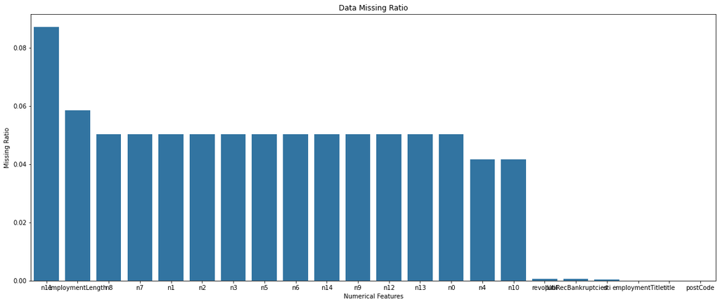

```python
# 缺失值统计可视化

import matplotlib.pyplot as plt
import seaborn as sns

missing_ratio = data.isnull().mean().sort_values(ascending = False)
missing_ratio = missing_ratio[missing_ratio > 0]

plt.figure(figsize = (20,8))
sns.barplot(x = missing_ratio.index, y = missing_ratio.values)
plt.title('Data Missing Ratio')
plt.xlabel('Numerical Features')
plt.ylabel('Missing Ratio')
plt.show()
```

解释：上述结果表明，单纯对于缺失值进行删除，并不是理想的选择。 考虑数值型变量用中位数代替，分类变量用众数代替，因此最好是在训练集和测试集划分之后归于preprocessor中，避免样本数据清洗从测试集数据中学习分布。

## 阶段二：数据预处理

### 任务2.3:重复值处理与数据一致性检查

```python
# 重复值检测

data.duplicated().sum()
```

```
0
```

```python
data['id'].duplicated().sum()
```

```
0
```

### 任务2.2:异常值检测与处理(箱线图、3σ原则、业务规则)

```python
# 异常值检测

data[numerical_cols].describe().T
```

|  | count | mean | std | min | 25% | 50% | 75% | max |
| --- | --- | --- | --- | --- | --- | --- | --- | --- |
| loanAmnt | 800000.0 | 14416.818875 | 8716.086178 | 500.00 | 8000.00 | 12000.000 | 20000.00 | 40000.00 |
| interestRate | 800000.0 | 13.238391 | 4.765757 | 5.31 | 9.75 | 12.740 | 15.99 | 30.99 |
| installment | 800000.0 | 437.947723 | 261.460393 | 15.69 | 248.45 | 375.135 | 580.71 | 1715.42 |
| annualIncome | 800000.0 | 76133.910493 | 68947.513672 | 0.00 | 45600.00 | 65000.000 | 90000.00 | 10999200.00 |
| dti | 799761.0 | 18.284557 | 11.150155 | -1.00 | 11.79 | 17.610 | 24.06 | 999.00 |
| delinquency_2years | 800000.0 | 0.318239 | 0.880325 | 0.00 | 0.00 | 0.000 | 0.00 | 39.00 |
| ficoRangeLow | 800000.0 | 696.204081 | 31.865995 | 630.00 | 670.00 | 690.000 | 710.00 | 845.00 |
| ficoRangeHigh | 800000.0 | 700.204226 | 31.866674 | 634.00 | 674.00 | 694.000 | 714.00 | 850.00 |
| openAcc | 800000.0 | 11.598020 | 5.475286 | 0.00 | 8.00 | 11.000 | 14.00 | 86.00 |
| pubRec | 800000.0 | 0.214915 | 0.606467 | 0.00 | 0.00 | 0.000 | 0.00 | 86.00 |
| pubRecBankruptcies | 799595.0 | 0.134163 | 0.377471 | 0.00 | 0.00 | 0.000 | 0.00 | 12.00 |
| revolBal | 800000.0 | 16228.706505 | 22458.020544 | 0.00 | 5944.00 | 11132.000 | 19734.00 | 2904836.00 |
| revolUtil | 799469.0 | 51.790734 | 24.516126 | 0.00 | 33.40 | 52.100 | 70.70 | 892.30 |
| totalAcc | 800000.0 | 24.998861 | 11.999201 | 2.00 | 16.00 | 23.000 | 32.00 | 162.00 |
| n0 | 759730.0 | 0.511932 | 1.333266 | 0.00 | 0.00 | 0.000 | 0.00 | 51.00 |
| n1 | 759730.0 | 3.642330 | 2.246825 | 0.00 | 2.00 | 3.000 | 5.00 | 33.00 |
| n2 | 759730.0 | 5.642648 | 3.302810 | 0.00 | 3.00 | 5.000 | 7.00 | 63.00 |
| n3 | 759730.0 | 5.642648 | 3.302810 | 0.00 | 3.00 | 5.000 | 7.00 | 63.00 |
| n4 | 766761.0 | 4.735641 | 2.949969 | 0.00 | 3.00 | 4.000 | 6.00 | 49.00 |
| n5 | 759730.0 | 8.107937 | 4.799210 | 0.00 | 5.00 | 7.000 | 11.00 | 70.00 |
| n6 | 759730.0 | 8.575994 | 7.400536 | 0.00 | 4.00 | 7.000 | 11.00 | 132.00 |
| n7 | 759730.0 | 8.282953 | 4.561689 | 0.00 | 5.00 | 7.000 | 10.00 | 79.00 |
| n8 | 759729.0 | 14.622488 | 8.124610 | 1.00 | 9.00 | 13.000 | 19.00 | 128.00 |
| n9 | 759730.0 | 5.592345 | 3.216184 | 0.00 | 3.00 | 5.000 | 7.00 | 45.00 |
| n10 | 766761.0 | 11.643896 | 5.484104 | 0.00 | 8.00 | 11.000 | 14.00 | 82.00 |
| n11 | 730248.0 | 0.000815 | 0.030075 | 0.00 | 0.00 | 0.000 | 0.00 | 4.00 |
| n12 | 759730.0 | 0.003384 | 0.062041 | 0.00 | 0.00 | 0.000 | 0.00 | 4.00 |
| n13 | 759730.0 | 0.089366 | 0.509069 | 0.00 | 0.00 | 0.000 | 0.00 | 39.00 |
| n14 | 759730.0 | 2.178606 | 1.844377 | 0.00 | 1.00 | 2.000 | 3.00 | 30.00 |

```python
# 业务规则检测

print('dti < 0:',f"{(data['dti'] < 0).sum()}个")
print('dti < 0:',data[data['dti'] < 0]['dti'].value_counts())

print('dti > 100:',f"{(data['dti'] > 100).sum()}个")
print('dti > 100:',data[data['dti'] > 100]['dti'].value_counts().head(20))
```

```
dti < 0: 2个
dti < 0: dti
-1.0    2
Name: count, dtype: int64
dti > 100: 323个
dti > 100: dti
999.00    24
102.73     2
115.01     1
147.36     1
100.23     1
141.94     1
120.66     1
248.95     1
441.50     1
150.05     1
106.54     1
102.52     1
174.86     1
185.95     1
126.61     1
118.22     1
494.23     1
111.15     1
260.24     1
206.00     1
Name: count, dtype: int64
```

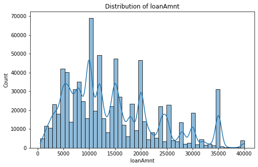

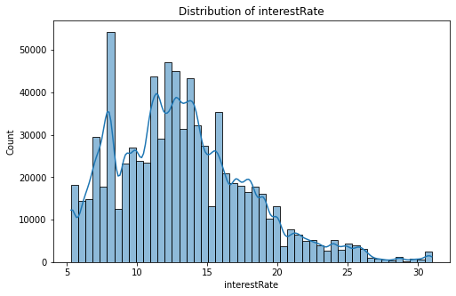

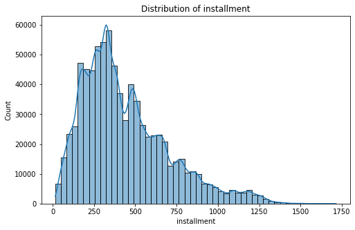

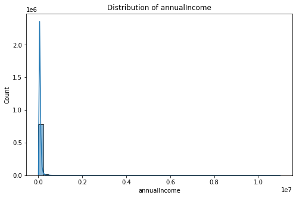

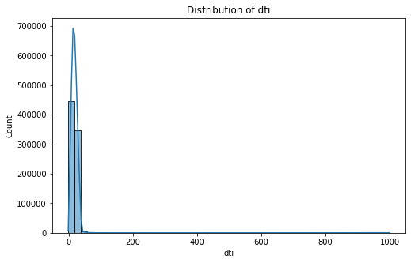

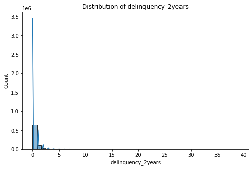

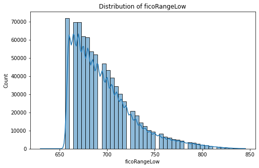

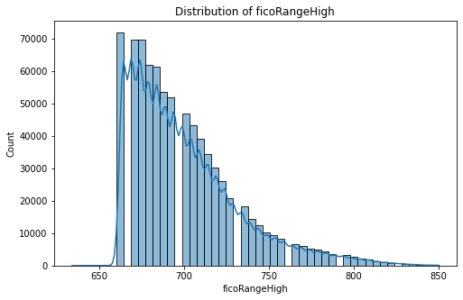

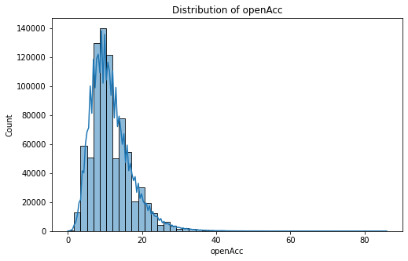

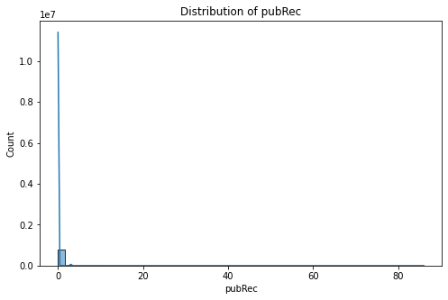

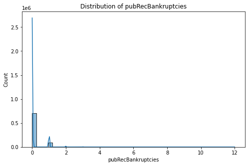

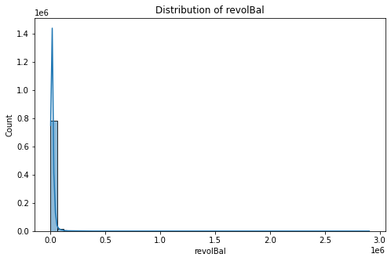

[18 more figures not shown]

```python
# 直方图

for col in numerical_cols:
    plt.figure(figsize = (8,5))
    sns.histplot(data[col], bins = 50, kde = True)
    plt.title(f'Distribution of {col}')
    plt.show()
```

```python
# 因为大部分数据呈现偏态（右偏），考虑用IQR检测（代替3σ原则）

result = []
for col in numerical_cols:
    Q1 = data[col].quantile(0.25)
    Q3 = data[col].quantile(0.75)
    IQR = Q3 - Q1
    lower = Q1 - 1.5*IQR
    upper = Q3 + 1.5*IQR
    outlier_count = data[(data[col] < lower) | (data[col] > upper)][col].count()
    outlier_ratio = outlier_count / data[col].notnull().sum()

    result.append({
        'Q1': Q1,
        'Q3': Q3,
        'IQR': IQR,
        'lower': lower,
        'upper': upper,
        'outlier_count': outlier_count,
        'outlier_ratio': outlier_ratio,
    })

IQR_check_df = pd.DataFrame(result, index = numerical_cols).sort_values('outlier_ratio', ascending = False)
IQR_check_df
```

|  | Q1 | Q3 | IQR | lower | upper | outlier_count | outlier_ratio |
| --- | --- | --- | --- | --- | --- | --- | --- |
| n0 | 0.00 | 0.00 | 0.00 | 0.000 | 0.000 | 180303 | 0.237325 |
| delinquency_2years | 0.00 | 0.00 | 0.00 | 0.000 | 0.000 | 154285 | 0.192856 |
| pubRec | 0.00 | 0.00 | 0.00 | 0.000 | 0.000 | 135235 | 0.169044 |
| pubRecBankruptcies | 0.00 | 0.00 | 0.00 | 0.000 | 0.000 | 99519 | 0.124462 |
| n6 | 4.00 | 11.00 | 7.00 | -6.500 | 21.500 | 46771 | 0.061563 |
| revolBal | 5944.00 | 19734.00 | 13790.00 | -14741.000 | 40419.000 | 47355 | 0.059194 |
| n13 | 0.00 | 0.00 | 0.00 | 0.000 | 0.000 | 43599 | 0.057387 |
| annualIncome | 45600.00 | 90000.00 | 44400.00 | -21000.000 | 156600.000 | 39014 | 0.048767 |
| n4 | 3.00 | 6.00 | 3.00 | -1.500 | 10.500 | 33948 | 0.044275 |
| n7 | 5.00 | 10.00 | 5.00 | -2.500 | 17.500 | 32134 | 0.042297 |
| n10 | 8.00 | 14.00 | 6.00 | -1.000 | 23.000 | 26784 | 0.034931 |
| ficoRangeLow | 670.00 | 710.00 | 40.00 | 610.000 | 770.000 | 27667 | 0.034584 |
| ficoRangeHigh | 674.00 | 714.00 | 40.00 | 614.000 | 774.000 | 27667 | 0.034584 |
| openAcc | 8.00 | 14.00 | 6.00 | -1.000 | 23.000 | 27439 | 0.034299 |
| installment | 248.45 | 580.71 | 332.26 | -249.940 | 1079.100 | 24992 | 0.031240 |
| n3 | 3.00 | 7.00 | 4.00 | -3.000 | 13.000 | 21457 | 0.028243 |
| n2 | 3.00 | 7.00 | 4.00 | -3.000 | 13.000 | 21457 | 0.028243 |
| n14 | 1.00 | 3.00 | 2.00 | -2.000 | 6.000 | 20576 | 0.027083 |
| n9 | 3.00 | 7.00 | 4.00 | -3.000 | 13.000 | 19452 | 0.025604 |
| n8 | 9.00 | 19.00 | 10.00 | -6.000 | 34.000 | 19136 | 0.025188 |
| n5 | 5.00 | 11.00 | 6.00 | -4.000 | 20.000 | 16121 | 0.021219 |
| n1 | 2.00 | 5.00 | 3.00 | -2.500 | 9.500 | 15828 | 0.020834 |
| interestRate | 9.75 | 15.99 | 6.24 | 0.390 | 25.350 | 14803 | 0.018504 |
| totalAcc | 16.00 | 32.00 | 16.00 | -8.000 | 56.000 | 13446 | 0.016807 |
| loanAmnt | 8000.00 | 20000.00 | 12000.00 | -10000.000 | 38000.000 | 4246 | 0.005307 |
| dti | 11.79 | 24.06 | 12.27 | -6.615 | 42.465 | 3265 | 0.004082 |
| n12 | 0.00 | 0.00 | 0.00 | 0.000 | 0.000 | 2415 | 0.003179 |
| n11 | 0.00 | 0.00 | 0.00 | 0.000 | 0.000 | 566 | 0.000775 |
| revolUtil | 33.40 | 70.70 | 37.30 | -22.550 | 126.650 | 47 | 0.000059 |

解释：

1. dti 需要进行修正
2. annualIncome, revolBal , revolUtil , installment , loanAmnt 先保留，后续考虑对数变换
3. ficoRangeLow, ficoRangeHigh, totalAcc 保留

```python
# 异常值处理
# (1) dti 异常值改为缺失值
data['dti_cleaned'] = data['dti'].copy()
data.loc[data['dti_cleaned'] < 0,['dti_cleaned']] = np.nan
data.loc[data['dti_cleaned'] == 999, ['dti_cleaned']] = np.nan
```

```python
print((data['dti_cleaned'] < 0).sum())
print((data['dti_cleaned'] == 999).sum())
```

```
0
0
```

解释：初步的变量分类做了以下改动：

1. numerical_cols 新增'credit_history_years'
2. numerical_cols 将'dti'变为'dti_cleaned'

### 任务2.4:探索性数据分析(分布分析、相关性初步分析)

```python
# 虽然已经识别出isDefault是目标变量，但是无法判断0，1代表的含义，故通过探索性分析进行推测

# 因变量分布

counts = data['isDefault'].value_counts()
ratio = data['isDefault'].value_counts(normalize = True)

print(f'样本（0）：{counts[0]}，占比{ratio[0]:.2%}')
print(f'样本（1）：{counts[1]}，占比{ratio[1]:.2%}')
```

```
样本（0）：640390，占比80.05%
样本（1）：159610，占比19.95%
```

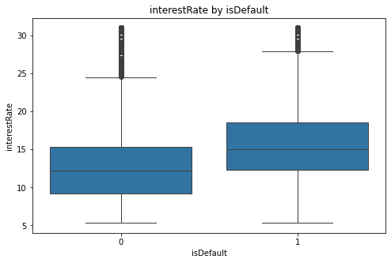

```python
# 假设'interestRate'越高，越容易违约

plt.figure(figsize = (8,5))
sns.boxplot(x = 'isDefault', y = 'interestRate', data = data)
plt.title('interestRate by isDefault')
plt.xlabel('isDefault')
plt.ylabel('interestRate')
plt.show()
```

```python
data.groupby('isDefault')['interestRate'].agg(['count','mean','median','max','min'])
```

| isDefault | count | mean | median | max | min |
| --- | --- | --- | --- | --- | --- |
| 0 | 640390 | 12.621685 | 12.18 | 30.99 | 5.31 |
| 1 | 159610 | 15.712749 | 15.05 | 30.99 | 5.31 |

解释：因为1组的利率平均高于0组，初步判断1为违约

```python
#ficoRangeLow

data.groupby('isDefault')['ficoRangeLow'].agg(['count','mean','median','max','min'])
```

| isDefault | count | mean | median | max | min |
| --- | --- | --- | --- | --- | --- |
| 0 | 640390 | 698.288028 | 690.0 | 845.0 | 630.0 |
| 1 | 159610 | 687.842836 | 680.0 | 845.0 | 660.0 |

```python
#dti_cleaned

data.groupby('isDefault')['dti_cleaned'].agg(['count','mean','median','max','min'])
```

| isDefault | count | mean | median | max | min |
| --- | --- | --- | --- | --- | --- |
| 0 | 640181 | 17.787150 | 17.11 | 991.57 | 0.0 |
| 1 | 159554 | 20.133034 | 19.74 | 831.97 | 0.0 |

解释：（考虑做一下假设检验，不够严谨）

1组借款人FICO信用评分区间的下界明显低于0组，加强了对于1为违约组判断的验证

1组dti（债务收入比）明显高于0组，加强了对于1为违约组判断的验证

```python
# 数值型数据EDA(去掉n0-n14)
key_numerical_cols = ['loanAmnt', 'interestRate', 'installment', 'annualIncome', 'dti_cleaned', 'delinquency_2years',
                      'ficoRangeLow', 'ficoRangeHigh', 'openAcc', 'pubRec', 'pubRecBankruptcies',
                      'revolBal', 'revolUtil', 'totalAcc','credit_history_years'
                      ]

data.groupby('isDefault')[key_numerical_cols].agg(['mean','median']).T
```

|  | isDefault | 0 | 1 |
| --- | --- | --- | --- |
| loanAmnt | mean | 14133.065749 | 15555.298070 |
|  | median | 12000.000000 | 14325.000000 |
| interestRate | mean | 12.621685 | 15.712749 |
|  | median | 12.180000 | 15.050000 |
| installment | mean | 431.222184 | 464.932048 |
|  | median | 368.080000 | 402.830000 |
| annualIncome | mean | 77606.514023 | 70225.505164 |
|  | median | 65000.000000 | 60000.000000 |
| dti_cleaned | mean | 17.723537 | 20.044852 |
|  | median | 17.100000 | 19.730000 |
| delinquency_2years | mean | 0.309368 | 0.353831 |
|  | median | 0.000000 | 0.000000 |
| ficoRangeLow | mean | 698.288028 | 687.842836 |
|  | median | 690.000000 | 680.000000 |
| ficoRangeHigh | mean | 702.288199 | 691.842873 |
|  | median | 694.000000 | 684.000000 |
| openAcc | mean | 11.524579 | 11.892682 |
|  | median | 11.000000 | 11.000000 |
| pubRec | mean | 0.206874 | 0.247177 |
|  | median | 0.000000 | 0.000000 |
| pubRecBankruptcies | mean | 0.129256 | 0.153850 |
|  | median | 0.000000 | 0.000000 |
| revolBal | mean | 16463.362656 | 15287.215043 |
|  | median | 11156.000000 | 11037.000000 |
| revolUtil | mean | 51.063113 | 54.710335 |
|  | median | 51.300000 | 55.500000 |
| totalAcc | mean | 25.075278 | 24.692262 |
|  | median | 23.000000 | 23.000000 |
| credit_history_years | mean | 16.404525 | 15.798478 |
|  | median | 15.000000 | 14.000000 |

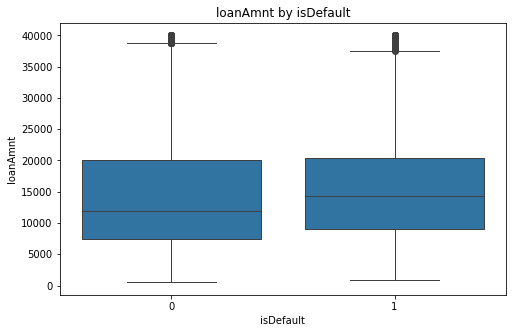

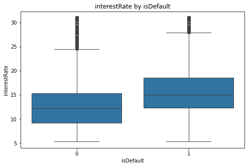

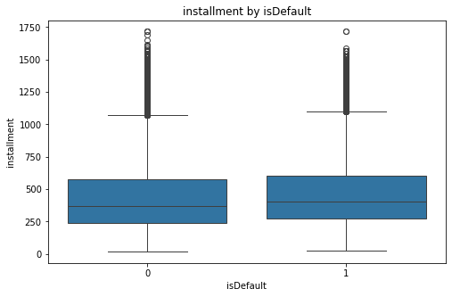

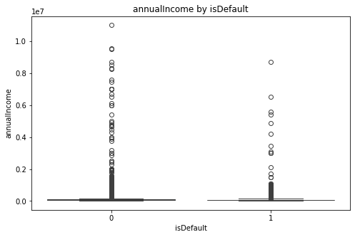

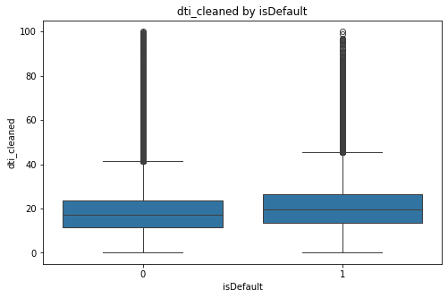

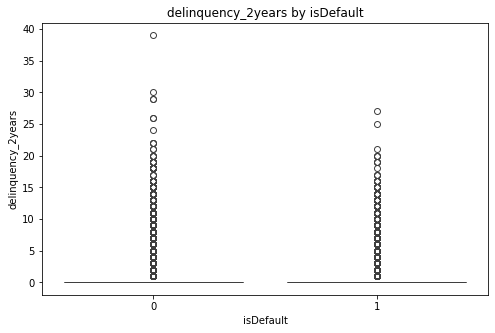

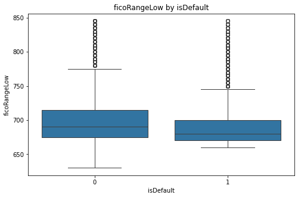

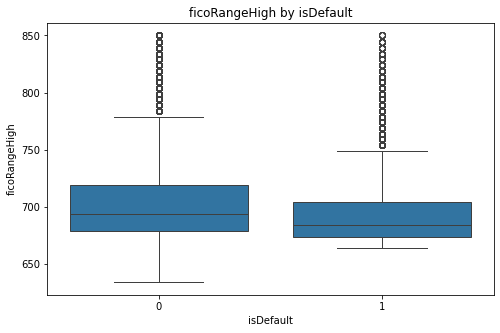

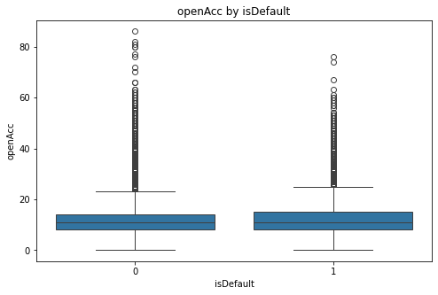

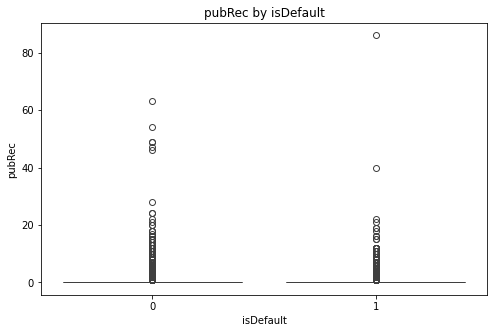

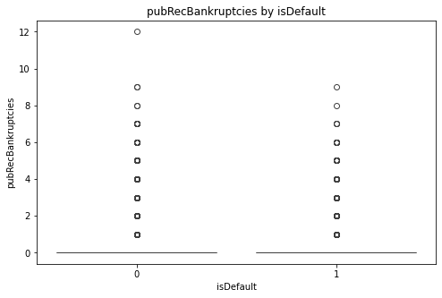

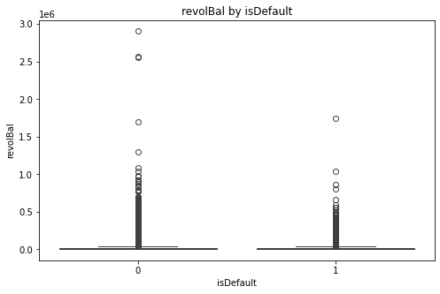

[3 more figures not shown]

```python
for col in key_numerical_cols:
    plt.figure(figsize = (8,5))
    sns.boxplot(x = 'isDefault', y = col, data = data)
    plt.title(f'{col} by isDefault')
    plt.xlabel('isDefault')
    plt.ylabel(col)
    plt.show()
```

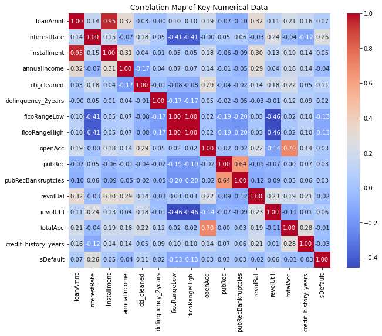

```python
# 对数值变量做相关性分析，画热力图

corr_cols = ['loanAmnt', 'interestRate', 'installment', 'annualIncome', 'dti_cleaned', 'delinquency_2years',
                      'ficoRangeLow', 'ficoRangeHigh', 'openAcc', 'pubRec', 'pubRecBankruptcies',
                      'revolBal', 'revolUtil', 'totalAcc','credit_history_years'
                      ,'isDefault']

plt.figure(figsize = (10,8))
corr_matrix = data[corr_cols].corr()
sns.heatmap(corr_matrix, annot = True, fmt = '.2f', cmap = 'coolwarm')
plt.title('Correlation Map of Key Numerical Data')
plt.show()
```

```python
# 分类数据EDA
# 分类变量： 10个
# ['homeOwnership', 'verificationStatus', 'purpose', 'regionCode', 'applicationType', 'initialListStatus', 'postCode', 'policyCode', 'title', 'employmentTitle']
# 有序变量：4个
# ['term', 'grade', 'subGrade', 'employmentLength']

# 首先要对'employmentLength'进行清洗
data['employmentLength'].value_counts(dropna = False)
```

```
employmentLength
10+ years    262753
2 years       72358
< 1 year      64237
3 years       64152
1 year        52489
5 years       50102
4 years       47985
NaN           46799
6 years       37254
8 years       36192
7 years       35407
9 years       30272
Name: count, dtype: int64
```

```python
def clean_employmentLength(x):
    if pd.isna(x):
        return np.nan
    elif x == '10+ years':
        return 10
    elif x == '< 1 year':
        return 0
    else:
        return int(str(x).replace('years','').replace('year',''))


data['employmentLength_clean'] = data['employmentLength'].apply(clean_employmentLength)
data[['employmentLength_clean','employmentLength']].head(10)

ordinal_cols = ['employmentLength_clean' if col == 'employmentLength' else col for col in ordinal_cols]
ordinal_cols
```

```
['term', 'grade', 'subGrade', 'employmentLength_clean']
```

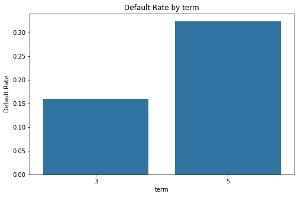

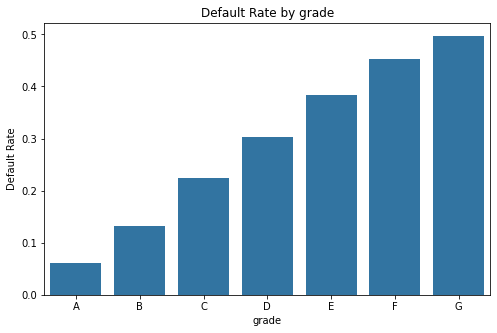

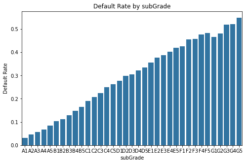

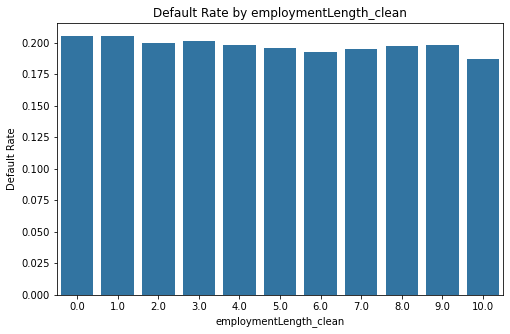

```python
# 有序变量EDA

for col in ordinal_cols:
    group_default_rate = data.groupby(col)['isDefault'].mean()
    plt.figure(figsize = (8,5))
    sns.barplot(x = group_default_rate.index, y = group_default_rate.values)
    plt.title(f'Default Rate by {col}')
    plt.xlabel(f'{col}')
    plt.ylabel(f'Default Rate')
    plt.show()
```